# 06.Character Encodings

## Encoding Systems

Now that different numbering systems have been discussed, its time to discuss how modern computers use the binary system to represent other values. This representation is known as character encoding. A simple example is to let the number one through twenty-six represent the capital letters A through Z. This encoding is shown below.

| 1 | 2 | 3 | 4 | 5 | 6 | 7 | 8 | 9 | 10 | 11 | 12 | 13 | 14 | 15 | 16 | 17 | 18 | 19 | 20 | 21 | 22 | 23 | 24 | 25 | 26 |
| --- | --- | --- | --- | --- | --- | --- | --- | --- | --- | --- | --- | --- | --- | --- | --- | --- | --- | --- | --- | --- | --- | --- | --- | --- | --- |
| A | B | C | D | E | F | G | H | I | J | K | L | M | N | O | P | Q | R | S | T | U | V | W | X | Y | Z |

With this simple encoding system, we could represent the words by the corresponding numbers. Consider the example shown below.

HELLO <---> 8, 5, 12, 12, 15

The word HELLO is represented, or encoded, by, or as, the numbers 8, 5, 12, 12, and 15. The reverse process may be used to decode a message. Look up the individual numbers from the message in the table and write the corresponding letter. Consider the numbers below.

23, 15, 18, 12, 4

What would these numbers represent? Decoding the numbers reveals that the word is WORLD. This simple encoding system may be expanded as other characters are needed. If a space character or lowercase letters were to be incorporated, they could be assigned a unique number (say starting at 27). The encoding could be expanded as much as needed. However, the task of encoding and decoding a character is dependent on having an agreed-upon character encoding system. Now let's say for whatever reason, the encoding system is defined as what is shown in the table below.

| 1 | 2 | 3 | 4 | 5 | 6 | 7 | 8 | 9 | 10 | 11 | 12 | 13 | 14 | 15 | 16 | 17 | 18 | 19 | 20 | 21 | 22 | 23 | 24 | 25 | 26 |
| --- | --- | --- | --- | --- | --- | --- | --- | --- | --- | --- | --- | --- | --- | --- | --- | --- | --- | --- | --- | --- | --- | --- | --- | --- | --- |
| Z | Y | X | W | V | U | T | S | R | Q | P | O | N | M | L | K | J | I | H | G | F | E | D | C | B | A |

Using the above encoding system, the message HELLO would become

HELLO <---> 19, 22, 15, 15, 12

This new encoding doesn't match what was previous determined for the HELLO message. Similarly, the numbers 23, 15, 18, 12, and 4 would be decoded as

23, 15, 18, 12, 4 <---> DLIOW

This decoding results in a nonsense word. It may be seen that the encoding system being used affects the outcome.

## ASCII Encoding System

Since it is crucial to determine what encoding system is being used, there are groups in the world that have created standards or agreed upon systems for different types of encodings. A prevalent kind of character encoding standard is the [American Standard Code for Information Interchange](https://en.wikipedia.org/wiki/ASCII) (ASCII, pronounced as ASS-kee). Another widespread encoding system is known as Unicode. ASCII and Unicode are just two examples of the numerous encoding systems standards that are out there. ASCII and Unicode are the most common, however. See [xkcd.com comic](https://xkcd.com/927/) for a humorous look at how different standards are created. ASCII is a character encoding system that dates back to the early days of modern computers. It was developed from an adaptation of [telegraph code](https://en.wikipedia.org/wiki/Telegraph_code) (something like [Morse code](https://en.wikipedia.org/wiki/Morse_code)). In more recent times, ASCII is probably most commonly known by the everyday user for what is known as ASCII art. ASCII art is simply the creation of an image from simple character values. A simple example of this is shown in Figure 1 below.

Figure 1: ASCII Art - Elephant

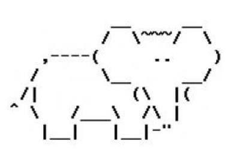

The image above depicts an elephant created from simple characters found on an ordinary keyboard.

See [here](https://upload.wikimedia.org/wikipedia/commons/7/73/Roflcopter.gif) and [here](http://www.melminnella.com/wp-content/uploads/2012/02/ASCIIdwight.jpg) for other examples of ASCII art.

ASCII art is somewhat unrelated to the ASCII character encoding system. ASCII art could just as well have been created from Unicode characters or some other encoding system. ASCII system has 128 different characters in the system with two different types of characters. The two types are

- Control Characters

They are the first 32 and the very last character. These characters don't have any actual symbol associated with them, but they represent various information used by a computer. Table 1 shown below lists the control characters of the ASCII system.

Table 1: ASCII Control Characters

| Decimal Value | Character | Description |  | Decimal Value | Character | Description |
| --- | --- | --- | --- | --- | --- | --- |
| 0 | NUL | null |  | 17 | DC1 | device control 1 |
| 1 | SOH | start of heading |  | 18 | DC2 | device control 2 |
| 2 | STX | start of text |  | 19 | DC3 | device control 3 |
| 3 | ETX | end of text |  | 20 | DC4 | device control 4 |
| 4 | EOT | end of transmission |  | 21 | NAK | negative acknowledge |
| 5 | ENQ | enquiry |  | 22 | SYN | synchronous idle |
| 6 | ACK | acknowledge |  | 23 | ETB | end of transmission block |
| 7 | BEL | bell |  | 24 | CAN | cancel |
| 8 | BS | backspace |  | 25 | EM | end of medium |
| 9 | TAB | horizontal tab |  | 26 | SUB | substitute |
| 10 | LF | line feed, new line |  | 27 | ESC | escape |
| 11 | VT | vertical tab |  | 28 | FS | file separator |
| 12 | FF | form feed, new page |  | 29 | GS | group separator |
| 13 | CR | carriage return |  | 30 | RS | record separator |
| 14 | SO | shift out |  | 31 | US | unit separator |
| 15 | SI | shift in |  | 127 | DEL | delete |
| 16 | DLE | data link escape |  |  |  |  |

- Printable Characters

Printable characters are the other type of characters of the ASCII system. These characters are symbols that are typically thought of when you are thinking of a character or symbol. They range from decimal values of 32 to 126. Table 2 below shows the printable characters of the ASCII system.

Table 2: ASCII Printable Characters

| Decimal Value | Character |  | Decimal Value | Character |  | Decimal Value | Character |  | Decimal Value | Character |  | Decimal Value | Character |  | Decimal Value | Character |
| --- | --- | --- | --- | --- | --- | --- | --- | --- | --- | --- | --- | --- | --- | --- | --- | --- |
| 32 | space |  | 48 | 0 |  | 64 | @ |  | 80 | P |  | 96 | ` |  | 112 | p |
| 33 | ! |  | 49 | 1 |  | 65 | A |  | 81 | Q |  | 97 | a |  | 113 | q |
| 34 | " |  | 50 | 2 |  | 66 | B |  | 82 | R |  | 98 | b |  | 114 | r |
| 35 | # |  | 51 | 3 |  | 67 | C |  | 83 | S |  | 99 | c |  | 115 | s |
| 36 | $ |  | 52 | 4 |  | 68 | D |  | 84 | T |  | 100 | d |  | 116 | t |
| 37 | % |  | 53 | 5 |  | 69 | E |  | 85 | U |  | 101 | e |  | 117 | u |
| 38 | & |  | 54 | 6 |  | 70 | F |  | 86 | V |  | 102 | f |  | 118 | v |
| 39 | ' |  | 55 | 7 |  | 71 | G |  | 87 | W |  | 103 | g |  | 119 | w |
| 40 | ( |  | 56 | 8 |  | 72 | H |  | 88 | X |  | 104 | h |  | 120 | x |
| 41 | ) |  | 57 | 9 |  | 73 | I |  | 89 | Y |  | 105 | i |  | 121 | y |
| 42 | * |  | 58 | : |  | 74 | J |  | 90 | Z |  | 106 | j |  | 122 | z |
| 43 | + |  | 59 | ; |  | 75 | K |  | 91 | [ |  | 107 | k |  | 123 | { |
| 44 | , |  | 60 | < |  | 76 | L |  | 92 | \ |  | 108 | l |  | 124 | \| |
| 45 | - |  | 61 | = |  | 77 | M |  | 93 | ] |  | 109 | m |  | 125 | } |
| 46 | . |  | 62 | > |  | 78 | N |  | 94 | ^ |  | 110 | n |  | 126 | ~ |
| 47 | / |  | 63 | ? |  | 79 | O |  | 95 | _ |  | 111 | o |  |  |  |

## Unicode Encoding System

The ASCII system works well for numerous applications, but many languages have many other characters aside from the standard English alphabet. Support for a range of different characters is one of the reasons why Unicode was developed.

There are many different versions of Unicode, but probably the most common is known as UTF-8.

UTF-8 uses 1 to 4 bytes of data to represent characters.

Four bytes of data means that there are 2 to the 32 power of available character representations (that is 4,294,967,296 characters that it can represent).

The available character values will not be listed here for apparent reasons, but they can be viewed [here](https://www.fileformat.info/info/charset/UTF-8/list.htm).